```python
from __future__ import print_function, division
import math
import torch
import torch.nn as nn
import torch.optim as optim
from torch.optim import lr_scheduler
import numpy as np
import torchvision
from torchvision import datasets, models, transforms
import matplotlib.pyplot as plt
import time
import os
import copy
import visualize_model
from torch.autograd import Variable
from torch.optim.optimizer import Optimizer
```

```python
print (torch.__version__)
```

```
1.0.0
```

# We will use torchvision and torch.utils.data packages for loading the data.

This dataset is a very small subset of imagenet, along with some raw data of frogs from the wild that I collected . frogs pictures from photographs work on "Unsplash"! Please support unsplash for their amazing free pictures .

```python
# Data augmentation and normalization for training
# Just normalization for validation
data_transforms = {
    'train': transforms.Compose([
        transforms.RandomResizedCrop(224),
        transforms.RandomHorizontalFlip(),
        transforms.ToTensor(),
        transforms.Normalize([0.485, 0.456, 0.406], [0.229, 0.224, 0.225])
    ]),
    'val': transforms.Compose([
        transforms.Resize(256),
        transforms.CenterCrop(224),
        transforms.ToTensor(),
        transforms.Normalize([0.485, 0.456, 0.406], [0.229, 0.224, 0.225])
    ]),
}
# By increasing the batch_size to 16 from 4, I could bring the frogs also
data_dir = '../../data'
image_datasets = {x: datasets.ImageFolder(os.path.join(data_dir, x),
                                          data_transforms[x])
                  for x in ['train', 'val']}
dataloaders = {x: torch.utils.data.DataLoader(image_datasets[x], batch_size=16,
                                             shuffle=True, num_workers=4)
              for x in ['train', 'val']}
dataset_sizes = {x: len(image_datasets[x]) for x in ['train', 'val']}
class_names = image_datasets['train'].classes

device = torch.device("cuda:0" if torch.cuda.is_available() else "cpu")
```

# Visualize a few images

Let’s visualize a few training images so as to understand the data augmentations.

```python
def imshow(inp, title=None):
    """Imshow for Tensor."""
    inp = inp.numpy().transpose((1, 2, 0))
    mean = np.array([0.485, 0.456, 0.406])
    std = np.array([0.229, 0.224, 0.225])
    inp = std * inp + mean
    inp = np.clip(inp, 0, 1)
    plt.imshow(inp)
    if title is not None:
        plt.title(title)
```

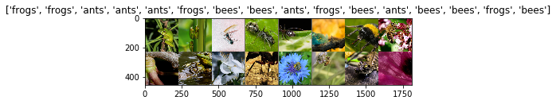

```python
# Get a batch of training data
inputs, classes = next(iter(dataloaders['train']))

# Make a grid from batch
out = torchvision.utils.make_grid(inputs)

imshow(out, title=[class_names[x] for x in classes])
```

```python
def train_model(model, criterion, optimizer, scheduler, num_epochs=25):
    since = time.time()

    best_model_wts = copy.deepcopy(model.state_dict())
    best_acc = 0.0

    for epoch in range(num_epochs):
        print('Epoch {}/{}'.format(epoch, num_epochs - 1))
        print('-' * 10)

        # Each epoch has a training and validation phase
        for phase in ['train', 'val']:
            if phase == 'train':
                scheduler.step()
                model.train()  # Set model to training mode
            else:
                model.eval()   # Set model to evaluate mode

            running_loss = 0.0
            running_corrects = 0

            # Iterate over data.
            for inputs, labels in dataloaders[phase]:
                inputs = inputs.to(device)
                labels = labels.to(device)

                # zero the parameter gradients
                optimizer.zero_grad()

                # forward
                # track history if only in train
                with torch.set_grad_enabled(phase == 'train'):
                    outputs = model(inputs)
                    _, preds = torch.max(outputs, 1)
                    loss = criterion(outputs, labels)

                    # backward + optimize only if in training phase
                    if phase == 'train':
                        loss.backward()
                        optimizer.step()

                # statistics
                running_loss += loss.item() * inputs.size(0)
                running_corrects += torch.sum(preds == labels.data)

            epoch_loss = running_loss / dataset_sizes[phase]
            epoch_acc = running_corrects.double() / dataset_sizes[phase]

            print('{} Loss: {:.4f} Acc: {:.4f}'.format(
                phase, epoch_loss, epoch_acc))

            # deep copy the model
            if phase == 'val' and epoch_acc > best_acc:
                best_acc = epoch_acc
                best_model_wts = copy.deepcopy(model.state_dict())

        print()

    time_elapsed = time.time() - since
    print('Training complete in {:.0f}m {:.0f}s'.format(
        time_elapsed // 60, time_elapsed % 60))
    print('Best val Acc: {:4f}'.format(best_acc))

    # load best model weights
    model.load_state_dict(best_model_wts)
    return model
```

# Visualizing the model predictions

Generic function to display predictions for a few images

```python
def visualize_model(model, num_images=12):
    was_training = model.training
    model.eval()
    images_so_far = 0
    fig = plt.figure()

    with torch.no_grad():
        for i, (inputs, labels) in enumerate(dataloaders['val']):
            inputs = inputs.to(device)
            labels = labels.to(device)
            outputs = model(inputs)
            _, preds = torch.max(outputs, 1)

            for j in range(inputs.size()[0]):
                images_so_far += 1
                ax = plt.subplot(num_images//2, 2, images_so_far)
                ax.axis('off')
                ax.set_title('predicted: {}'.format(class_names[preds[j]]))
                imshow(inputs.cpu().data[j])

                if images_so_far == num_images:
                    model.train(mode=was_training)
                    return
        model.train(mode=was_training)
```

# Finetuning the convnet

Load a pretrained model and reset final fully connected layer.

```python
model_ft = models.resnet18(pretrained=True)
num_ftrs = model_ft.fc.in_features
model_ft.fc = nn.Linear(num_ftrs, 3)

model_ft = model_ft.to(device)

criterion = nn.CrossEntropyLoss()

# Observe that all parameters are being optimized
optimizer_ft = optim.SGD(model_ft.parameters(), lr=0.001, momentum=0.9)

# Decay LR by a factor of 0.1 every 7 epochs
exp_lr_scheduler = lr_scheduler.StepLR(optimizer_ft, step_size=7, gamma=0.1)
```

# Train and evaluate

It should take around 25-39 min on CPU. On GPU though, it takes less than a minute.

```python
model_ft = train_model(model_ft, criterion, optimizer_ft, exp_lr_scheduler,
                       num_epochs=25)
```

```
----------
train Loss: 0.8914 Acc: 0.6441
val Loss: 0.4186 Acc: 0.8623

----------
train Loss: 0.4881 Acc: 0.8576
val Loss: 0.2300 Acc: 0.9461

----------
train Loss: 0.4143 Acc: 0.8373
val Loss: 0.2610 Acc: 0.9102

----------
train Loss: 0.2328 Acc: 0.9153
val Loss: 0.1865 Acc: 0.9401

----------
train Loss: 0.2676 Acc: 0.9051
val Loss: 0.1859 Acc: 0.9401

----------
train Loss: 0.1911 Acc: 0.9492
val Loss: 0.1991 Acc: 0.9401

----------
train Loss: 0.1939 Acc: 0.9254
val Loss: 0.1940 Acc: 0.9401

----------
train Loss: 0.2239 Acc: 0.9186
val Loss: 0.1884 Acc: 0.9461

----------
train Loss: 0.1952 Acc: 0.9458
val Loss: 0.1923 Acc: 0.9461

----------
train Loss: 0.1691 Acc: 0.9322
val Loss: 0.1897 Acc: 0.9401

```

[output cut: 47 more lines]

```

----------
train Loss: 0.1588 Acc: 0.9390
val Loss: 0.1873 Acc: 0.9401

----------
train Loss: 0.1480 Acc: 0.9593
val Loss: 0.1917 Acc: 0.9401

----------
train Loss: 0.1378 Acc: 0.9492
val Loss: 0.1839 Acc: 0.9461

Training complete in 34m 59s
Best val Acc: 0.946108
```

[figure not shown]

```python
visualize_model(model_ft)
```

# ConvNet as fixed feature extractor

Here, we need to freeze all the network except the final layer. We need to set requires_grad == False to freeze the parameters so that the gradients are not computed in backward().

```python
model_conv = torchvision.models.resnet18(pretrained=True)
for param in model_conv.parameters():
    param.requires_grad = False

# Parameters of newly constructed modules have requires_grad=True by default
num_ftrs = model_conv.fc.in_features
model_conv.fc = nn.Linear(num_ftrs, 3)

model_conv = model_conv.to(device)

criterion = nn.CrossEntropyLoss()

# Observe that only parameters of final layer are being optimized as
# opposed to before.
optimizer_conv = optim.SGD(model_conv.fc.parameters(), lr=0.001, momentum=0.9)

# Decay LR by a factor of 0.1 every 7 epochs
exp_lr_scheduler = lr_scheduler.StepLR(optimizer_conv, step_size=7, gamma=0.1)
```

# Train and evaluate

On CPU this will take about half the time compared to previous scenario. This is expected as gradients don’t need to be computed for most of the network. However, forward does need to be computed.

```python
model_conv = train_model(model_conv, criterion, optimizer_conv,
                         exp_lr_scheduler, num_epochs=25)
```

```
----------
train Loss: 1.0719 Acc: 0.4814
val Loss: 0.6560 Acc: 0.8204

----------
train Loss: 0.6593 Acc: 0.7424
val Loss: 0.4130 Acc: 0.9042

----------
train Loss: 0.4683 Acc: 0.8542
val Loss: 0.2948 Acc: 0.9341

----------
train Loss: 0.4354 Acc: 0.8441
val Loss: 0.2595 Acc: 0.9521

----------
train Loss: 0.3750 Acc: 0.8712
val Loss: 0.2643 Acc: 0.9341

----------
train Loss: 0.3933 Acc: 0.8576
val Loss: 0.2423 Acc: 0.9341

----------
train Loss: 0.3087 Acc: 0.8915
val Loss: 0.2029 Acc: 0.9581

----------
train Loss: 0.3384 Acc: 0.8780
val Loss: 0.2140 Acc: 0.9521

----------
train Loss: 0.2952 Acc: 0.8949
val Loss: 0.2097 Acc: 0.9521

----------
train Loss: 0.3608 Acc: 0.8746
val Loss: 0.2042 Acc: 0.9461

```

[output cut: 47 more lines]

```

----------
train Loss: 0.3577 Acc: 0.8441
val Loss: 0.2026 Acc: 0.9461

----------
train Loss: 0.3301 Acc: 0.8915
val Loss: 0.2042 Acc: 0.9461

----------
train Loss: 0.2659 Acc: 0.9220
val Loss: 0.2004 Acc: 0.9461

Training complete in 15m 41s
Best val Acc: 0.958084
```

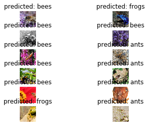

```python
visualize_model(model_conv)
```